# firma_genetica_autismo

Cristopher Valenzuela

9 de marzo de 2022

# Búsqueda de genes diferencialmente expresados para el autismo

En este análisis se obtendrán genes diferencialmente expresados, obtenidos del repositorio público Geo Ómnibus, específicamente son datos de pacientes con autismo y controles sanos. El acceso a los datos se encuentran con acceso "GSE42133".

Los niveles de expresión génica de leucocitos se analizaron en bebés y niños pequeños autistas y en desarrollo típico con el propósito de identificar las firmas de expresión génica relevantes para el cerebro autista y ayudar en la clasificación de los sujetos.

```r
#carga de datos
datos <-read.table("C:/Users/Cristopher/Desktop/datos omicos git/autismo/GSE42133_non-normalized_data.txt",sep = "\t",header = TRUE)

probesID<-datos[,1]
exprMat<-datos[,-1]
subsID<-colnames(exprMat)
exprMat<-as.matrix(exprMat)
head(exprMat[1:10,1:10])
```

```
##      LD378.01.AVG_Signal LD378.01.BEAD_STDERR LD378.01.Avg_NBEADS
## [1,]            51.14779             2.010076                   8
## [2,]            45.88997             2.644619                  12
## [3,]            37.78681             1.286053                  18
## [4,]            48.88101             2.390645                  31
## [5,]            39.38229             1.820489                  27
## [6,]            38.74038             1.519902                  28
##      LD378.01.Detection.Pval LD387.01.AVG_Signal LD387.01.BEAD_STDERR
## [1,]              0.03506494            33.99569             2.547076
## [2,]              0.17272730            38.94940             2.546125
## [3,]              0.70000000            35.00112             1.596366
## [4,]              0.06883117            40.72334             2.904632
## [5,]              0.58961040            31.75694             1.595503
## [6,]              0.62467530            31.32872             1.548701
##      LD387.01.Avg_NBEADS LD387.01.Detection.Pval LD388.01.AVG_Signal
## [1,]                  18              0.44675320            45.43645
## [2,]                   9              0.08571429            50.01560
## [3,]                  26              0.34545450            47.12896
## [4,]                  22              0.05064935            47.92087
## [5,]                  23              0.65974030            38.82387
## [6,]                  23              0.69220780            38.96399
##      LD388.01.BEAD_STDERR
## [1,]             3.319198
## [2,]             2.524028
## [3,]             2.619844
## [4,]             2.397440
## [5,]             2.685669
## [6,]             2.598142
```

Guardamos las sondas y los identificadores de sujeto (ID) en las variables probesID y subsID. La función normalizeBetweenArrays de limma realiza la normalización entre sujetos usando el método cuantil

```r
library(limma)
exprNormdat<-normalizeBetweenArrays(exprMat, method="quantile")
exprNormdat[1:5,1:5]
```

```
##      LD378.01.AVG_Signal LD378.01.BEAD_STDERR LD378.01.Avg_NBEADS
## [1,]            19.17282             13.81060            9.157992
## [2,]            17.01510             16.35666           11.203494
## [3,]            13.47213             10.41108           14.993008
## [4,]            18.22960             15.40202          481.933829
## [5,]            14.19589             12.94065           85.893481
##      LD378.01.Detection.Pval LD387.01.AVG_Signal
## [1,]                16.24734            15.06672
## [2,]                17.81591            17.66159
## [3,]                67.41116            15.61205
## [4,]                16.68937            18.50536
## [5,]                42.31926            13.81753
```

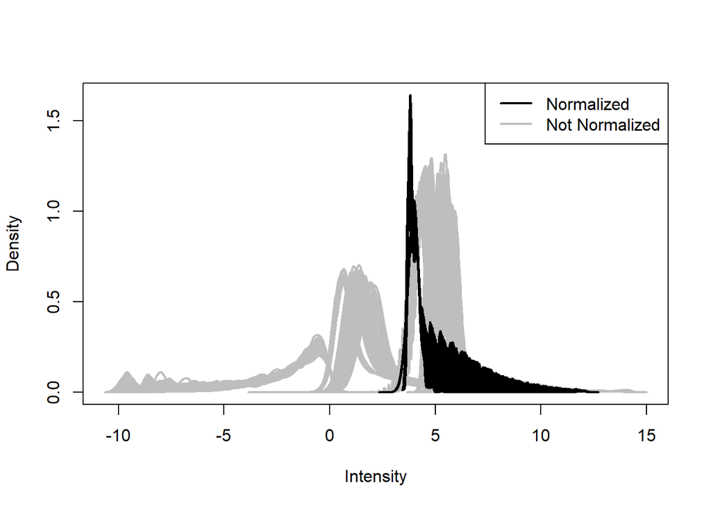

```r
L2exprMat<-log2(exprMat)
L2exprNorm<-log2(exprNormdat)
comp<-cbind(L2exprMat,L2exprNorm)
nsubs<-ncol(L2exprMat)
gr<-factor(rep(c("Not Normalized","Normalized"),each=nsubs))
plotDensities(comp, group = gr, col=c("black","grey"), legend="topright")
```

```r
library(Biobase)
phenoDF <- data.frame(subsID, row.names=subsID)
phenodat <- AnnotatedDataFrame(data=phenoDF)
featureDF <- data.frame(probesID, row.names=probesID)
featureData <- AnnotatedDataFrame(data=featureDF)
exprNorm <- ExpressionSet(assayData=L2exprNorm,phenoData=phenodat, featureData=featureData)
show(exprNorm)
```

```
## ExpressionSet (storageMode: lockedEnvironment)
## assayData: 47323 features, 588 samples
##   element names: exprs
## protocolData: none
## phenoData
##   sampleNames: LD378.01.AVG_Signal LD378.01.BEAD_STDERR ...
##     LD883.01.Detection.Pval (588 total)
##   varLabels: subsID
##   varMetadata: labelDescription
## featureData
##   featureNames: ILMN_1762337 ILMN_2055271 ... ILMN_2137536 (47323
##     total)
##   fvarLabels: probesID
##   fvarMetadata: labelDescription
## experimentData: use 'experimentData(object)'
## Annotation:
```

```r
Sys.setenv(VROOM_CONNECTION_SIZE = 131072*10)
readr::local_edition(1)
library(GEOquery)
gsm.expr <- getGEO("GSE42133", destdir = ".")
gsm.expr <- gsm.expr[[1]]
show(gsm.expr)
```

```
## ExpressionSet (storageMode: lockedEnvironment)
## assayData: 47323 features, 147 samples
##   element names: exprs
## protocolData: none
## phenoData
##   sampleNames: GSM1033105 GSM1033106 ... GSM1033255 (147 total)
##   varLabels: title geo_accession ... gender:ch1 (36 total)
##   varMetadata: labelDescription
## featureData
##   featureNames: ILMN_1343291 ILMN_1343295 ... ILMN_3311190 (47323
##     total)
##   fvarLabels: ID Species ... GB_ACC (30 total)
##   fvarMetadata: Column Description labelDescription
## experimentData: use 'experimentData(object)'
##   pubMedIds: 25739104
## 26668231
## Annotation: GPL10558
```

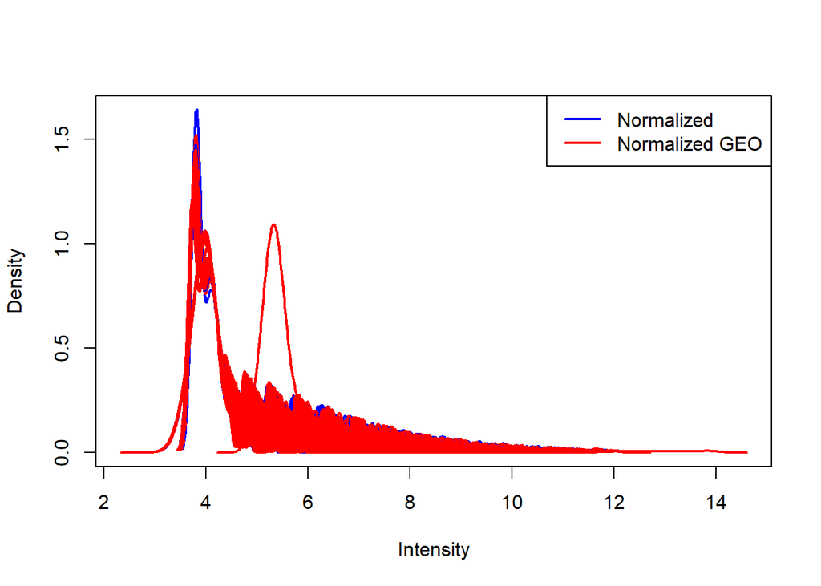

```r
probesIDsGEO<-as.character(fData(gsm.expr)$ID)
probesID<-as.character(fData(exprNorm)$probesID)
selprobes<-probesID%in%probesIDsGEO
nselprobes<-sum(selprobes)
exprNorm.sel<-exprNorm[selprobes,]
exprGEO<-exprs(gsm.expr)
expr<-exprs(exprNorm.sel)
comp<-cbind(exprGEO,expr)
nsubs<-ncol(exprGEO)
gr<-factor(rep(c("Normalized GEO","Normalized"),each=nsubs))
plotDensities(comp, group = gr, col=c("blue", "red"), legend="topright")
```

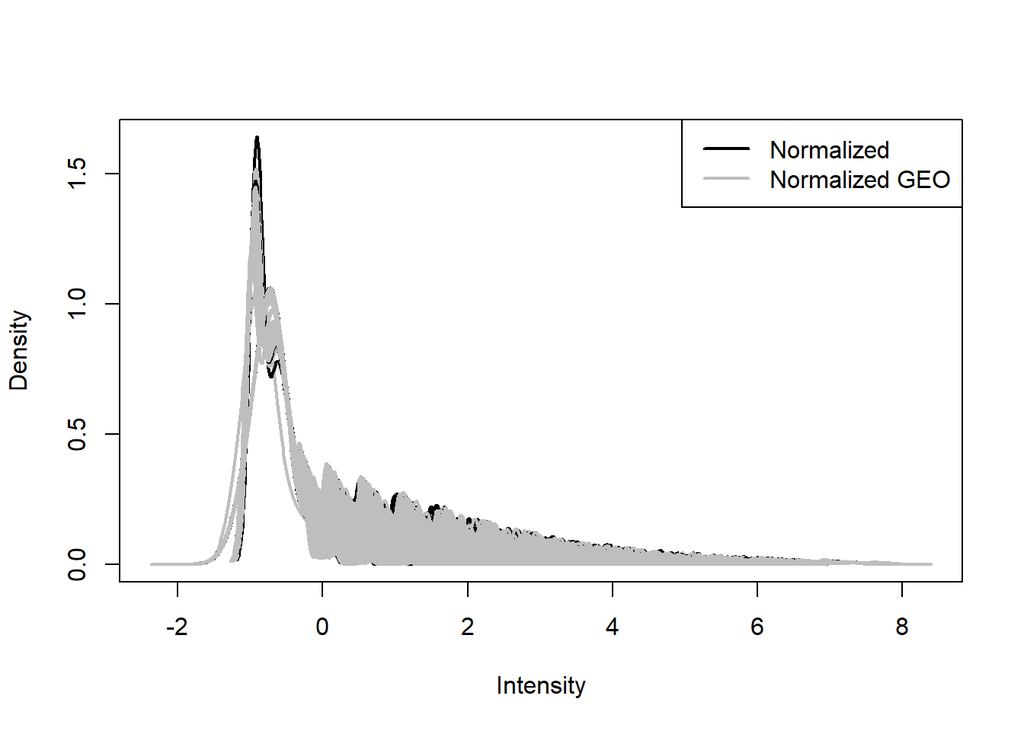

```r
exprScaledGEO <- scale(exprGEO, scale=FALSE)
exprScaled <- scale(expr, scale=FALSE)
comp<-cbind(exprScaledGEO,exprScaled)
plotDensities(comp, group = gr, col=c("black", "grey"), legend="topright")
```

```r
 exprGEO<-exprs(gsm.expr)

 #get phenotype data
 pheno <- pData(phenoData(gsm.expr))

  status <- pheno$`dx (diagnosis):ch1`
 status <- gsub("status: ","", as.character(status))
 fstatus <- factor(status)
 levels(fstatus)<-gsub(" ", "", levels(fstatus))

 table(fstatus)
```

```
## fstatus
##     ASD Control
##      91      56
```

no hay covarianzas en este estudio que valgan la pena estudiar.

```r
 library(sva)
 phenodat<-data.frame(fstatus)

 mod0 <- model.matrix( ~ 1, data = phenodat)
 mod <- model.matrix( ~ fstatus, data = phenodat)

 n.sv <- num.sv(exprGEO, mod, method = "leek" )
n.sv
```

```
## [1] 0
```

Existen 0 variables latentes

```r
svobj <- sva(exprGEO, mod, mod0, n.sv=2)
```

```
## Number of significant surrogate variables is:  2
## Iteration (out of 5 ):1  2  3  4  5
```

```r
names(svobj)
```

```
## [1] "sv"        "pprob.gam" "pprob.b"   "n.sv"
```

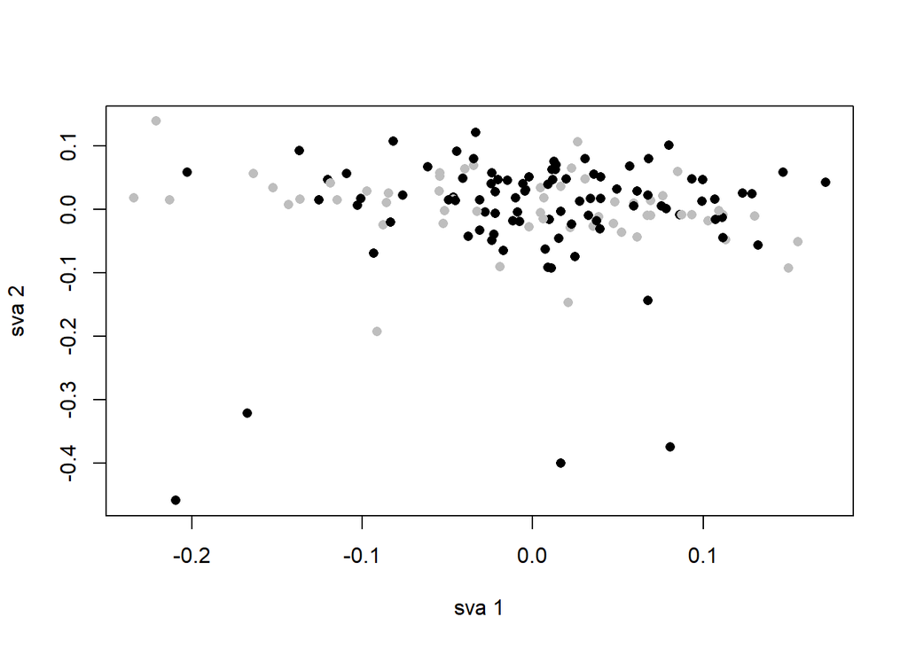

```r
col <- fstatus
 levels(col) <- c("black","grey")
 plot(svobj$sv[,1:2],col=as.character(col), xlab="sva 1",
 ylab="sva 2", pch=16)
```

No observamos ningun patron entre los casos y los controles.

```r
 summary(glm(phenodat$fstatus ~ svobj$sv, family="binomial" ))
```

```
##
## Call:
## glm(formula = phenodat$fstatus ~ svobj$sv, family = "binomial")
##
## Deviance Residuals:
##     Min       1Q   Median       3Q      Max
## -1.1541  -0.9865  -0.9227   1.3463   1.5490
##
## Coefficients:
##             Estimate Std. Error z value Pr(>|z|)
## (Intercept)  -0.4888     0.1705  -2.866  0.00416 **
## svobj$sv1    -1.9598     2.0615  -0.951  0.34178
## svobj$sv2     0.6275     2.0838   0.301  0.76332
## ---
## Signif. codes:  0 '***' 0.001 '**' 0.01 '*' 0.05 '.' 0.1 ' ' 1
##
## (Dispersion parameter for binomial family taken to be 1)
##
##     Null deviance: 195.37  on 146  degrees of freedom
## Residual deviance: 194.37  on 144  degrees of freedom
## AIC: 200.37
##
## Number of Fisher Scoring iterations: 4
```

Las variables no son estadisticamente significativas.

```r
summary(glm(svobj$sv[,1] ~ phenodat$fstatus))
```

```
##
## Call:
## glm(formula = svobj$sv[, 1] ~ phenodat$fstatus)
##
## Deviance Residuals:
##       Min         1Q     Median         3Q        Max
## -0.225757  -0.043742   0.006576   0.058311   0.166672
##
## Coefficients:
##                          Estimate Std. Error t value Pr(>|t|)
## (Intercept)              0.005089   0.008679   0.586    0.559
## phenodat$fstatusControl -0.013358   0.014061  -0.950    0.344
##
## (Dispersion parameter for gaussian family taken to be 0.006853893)
##
##     Null deviance: 1.00000  on 146  degrees of freedom
## Residual deviance: 0.99381  on 145  degrees of freedom
## AIC: -311.34
##
## Number of Fisher Scoring iterations: 2
```

Filtramos los genes y creamos la matriz para los contrastes

```r
 sv1 <- svobj$sv[,1]
 sv2 <- svobj$sv[,1]
 design <- model.matrix(~ 0 + fstatus + sv1 + sv2)
 colnames(design) <- c(levels(fstatus),"sva1","sva2")
```

Creamos los contrastes

```r
fit <- lmFit(exprGEO, design)
```

```
## Coefficients not estimable: sva2
```

```r
#En este caso el contraste sera uno solo entre pacientes con autismo y controles.

contrast.matrix <- makeContrasts(ASD-Control, levels=design)

contrast.matrix
```

```
##          Contrasts
## Levels    ASD - Control
##   ASD                 1
##   Control            -1
##   sva1                0
##   sva2                0
```

```r
fit2 <- contrasts.fit(fit, contrast.matrix)
fit2 <- eBayes(fit2)

#obtenemos el top de genes diferencialmente expresados que utilizaremos para crear una firma genetica

topTab_contraste <- topTable(fit2, coef="ASD - Control", adjust="fdr")
head(topTab_contraste)
```

```
##                   logFC   AveExpr         t      P.Value    adj.P.Val         B
## ILMN_1735360  0.1568857  9.893273  6.701556 3.987846e-10 1.521635e-05 12.647719
## ILMN_2075927  0.2261596 10.314148  6.610336 6.430849e-10 1.521635e-05 12.201164
## ILMN_3299478  0.1669237 12.206205  6.416024 1.759905e-09 2.776132e-05 11.260736
## ILMN_2210934  0.2962738  6.594257  6.215524 4.891243e-09 5.786707e-05 10.306494
## ILMN_3280402 -0.2788866  8.229150 -6.124356 7.740168e-09 7.325759e-05  9.878267
## ILMN_1813573  0.1971317  6.908708  6.004132 1.409683e-08 1.063055e-04  9.319166
```

# Anotacion de genes

```r
 annotatedTopTable <- function(topTab, anotPackage)
 {
  topTab <- cbind(PROBEID=rownames(topTab), topTab)
  myProbes <- rownames(topTab)
  thePackage <- eval(parse(text = anotPackage))
  geneAnots <- select(thePackage, myProbes, c("SYMBOL", "ENTREZID", "GENENAME"))
  annotatedTopTab<- merge(x=geneAnots, y=topTab, by.x="PROBEID", by.y="PROBEID")
 return(annotatedTopTab)
 }

library(illuminaHumanv4.db)

 topAnnotated_controlvsasd <- annotatedTopTable(topTab_contraste,
                                                    anotPackage="illuminaHumanv4.db")
```

# Visualizamos los genes diferencialmente expresados

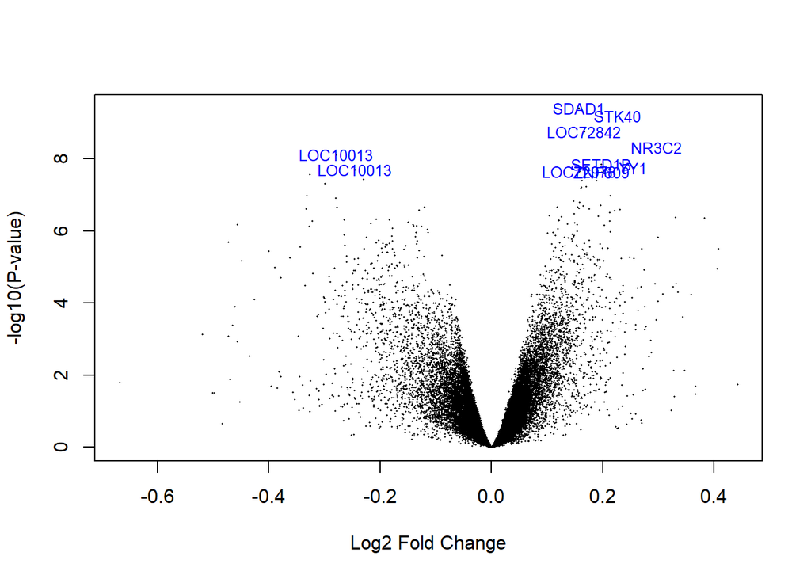

```r
genesIDs <- as.character(fData(gsm.expr)$ILMN_Gene)
names(genesIDs)<-rownames(gsm.expr)
genesIDsgenes=genesIDs[rownames(fit2)]

volcanoplot(fit2, coef = "ASD - Control", highlight=10, names=genesIDs, cex=0.2)
```

```r
library(limma)
  res<-decideTests(fit2, method="separate", adjust.method="fdr", p.value=0.1)
sum.res.rows<-apply(abs(res),1,sum)
res.selected<-res[sum.res.rows!=0,]
print(summary(res))
```

```
##        ASD - Control
## Down            1199
## NotSig         44609
## Up              1515
```

# Heatmap

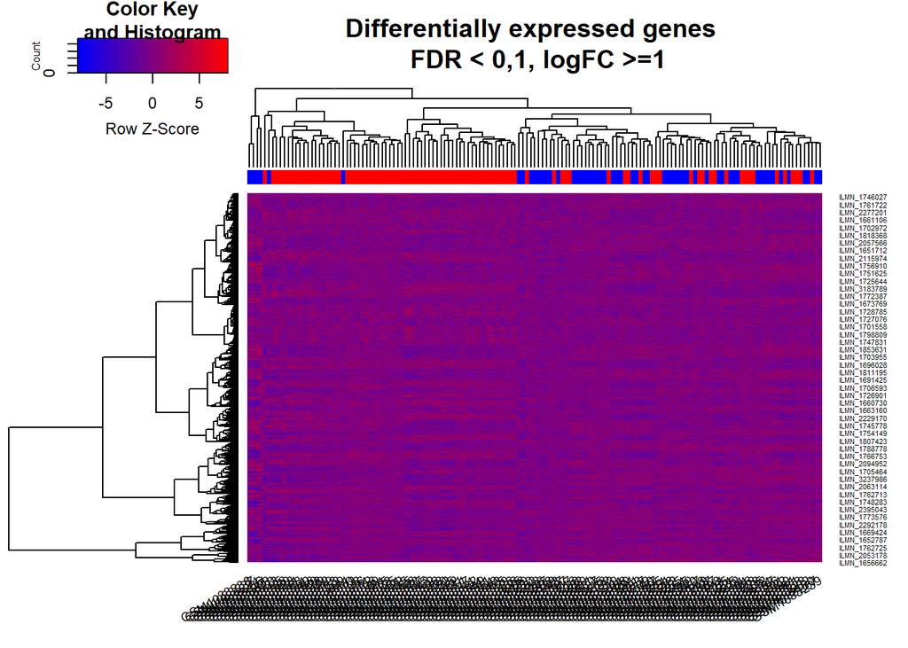

```r
probesInHeatmap <- rownames(res.selected)
HMdata <- exprGEO[rownames(exprGEO) %in% probesInHeatmap,]
write.csv(HMdata, file = file.path("C:\\Users\\Cristopher\\Desktop\\datos omicos git\\autismo\\heatmap.csv"))
my_palette <- colorRampPalette(c("blue", "red"))(n = 299)
library(gplots)



heatmap.2(HMdata,
           Rowv = TRUE,
           Colv = TRUE,
           dendrogram = "both",
           main = "Differentially expressed genes \n FDR < 0,1, logFC >=1",
           scale = "row",
           col = my_palette,
           sepcolor = "white",
           sepwidth = c(0.05,0.05),
           cexRow = 0.5,
           cexCol = 0.9,
           key = TRUE,
           keysize = 1.5,
           density.info = "histogram",
           ColSideColors = c(rep("red",91),rep("blue",56)),
           tracecol = NULL,
           srtCol = 30)
```

# Significacion biologica

```r
library(illuminaHumanv4.db)

listOfTables <- list(autismovscontrol = topTab_contraste)
listOfSelected <- list()
 for (i in 1:length(listOfTables)){
   # select the toptable
   topTab <- listOfTables[[i]]
   # select the genes to be included in the analysis
   whichGenes<-topTab["adj.P.Val"]<0.20
   selectedIDs <- rownames(topTab)[whichGenes]
   # convert the ID to Entrez
   EntrezIDs<- select(illuminaHumanv4.db, selectedIDs, c("ENTREZID"))
   EntrezIDs <- EntrezIDs$ENTREZID
   listOfSelected[[i]] <- EntrezIDs
   names(listOfSelected)[i] <- names(listOfTables)[i]
 }
```

```r
 sapply(listOfSelected, length)
```

```
## autismovscontrol
##               11
```

Tenemos solo 11 genes, no podriamos realizar un analisis de significacion biologica con tan pocos genes. Asi que en este estudio no realizamos tal analisis.

# Creación de firma genética con los genes diferencialmente expresados

```r
#creamos Z
x <- t(scale(t(exprGEO)))
#nos quedamos solo con los datos de pheno que necesitamos
metadata1<-pheno[,34:36]
#head(pheno)
discard1 <- apply(metadata1, 1, function(x) any( is.na(x)))
metadata1 <- metadata1[!discard1,]
x <- x[,which(colnames(x) %in% rownames(metadata1))]

all((colnames(x) == rownames(metadata1)) == TRUE)
```

```
## [1] TRUE
```

```r
#creamos objeto conjunto de ambos
data.juntos <- data.frame(metadata1, t(x))
colnames(data.juntos)[1:3] <- c('celula', 'diagnostico', 'sexo')

#transformamos en factor la variable diagnostico que sera la variable dependiente

data.juntos$diagnostico = as.numeric(factor(data.juntos$diagnostico))

#convertimos la variable diagnostico entre 0 y 1

data.juntos$diagnostico <- ifelse(data.juntos$diagnostico == '2', 0, 1)
data.juntos[1:10,1:10]
```

```
##               celula diagnostico sexo ILMN_1343291 ILMN_1343295 ILMN_1651199
## GSM1033105 leukocyte           1 male    0.3933604   0.04157132  -0.61945911
## GSM1033106 leukocyte           1 male    0.5894942  -0.13530914   0.09799739
## GSM1033107 leukocyte           1 male   -0.5218344  -0.90407113  -2.25738758
## GSM1033108 leukocyte           1 male    0.5894942  -1.70665547   0.95781852
## GSM1033109 leukocyte           0 male   -0.9107676  -1.64830172   0.60278675
## GSM1033110 leukocyte           0 male    1.7373032  -1.57961058  -0.74559386
## GSM1033111 leukocyte           1 male    1.1366033   1.15865334   0.62423975
## GSM1033112 leukocyte           0 male    1.1366033  -0.66515638  -0.03030929
## GSM1033113 leukocyte           1 male    0.3933604  -0.35604432  -0.64946058
## GSM1033114 leukocyte           0 male    1.7373032  -3.01144976  -1.04048151
##            ILMN_1651209 ILMN_1651210 ILMN_1651221 ILMN_1651228
## GSM1033105  -1.80259935   0.60884483   -1.3639420   0.39801874
## GSM1033106  -2.06377330   0.75558765    1.3360886   1.12003250
## GSM1033107   0.03602317   0.06308387    0.4795119  -0.40525734
## GSM1033108  -1.66550689   0.83671081    0.7666515   0.23907905
## GSM1033109  -0.72664844  -0.15558484   -0.6296344  -0.08330255
## GSM1033110  -1.43274477  -0.01059398   -1.0527818  -0.21592291
## GSM1033111  -0.64417660  -1.44576043    0.5008889   0.42111010
## GSM1033112  -0.74473768   0.42956831   -0.3504662  -0.29872582
## GSM1033113   0.37955780  -1.53645302   -0.9190727  -0.89401575
## GSM1033114  -0.95699410  -1.25668751   -0.5569114   0.54871138
```

Obtenemos que 0 seran los controles y 1 seran los pacientes con autismo. Procedemos ahora quedandonos solo con los genes mas diferencialmente expresados, por cuestiones computacionales.

```r
datos.regresion = data.juntos

#nos quedamos con los nombres de los genes diferencialmente expresados segun el contrastre antes realizado
plotdatam <- datos.regresion[,c('diagnostico', 'ILMN_1735360', 'ILMN_2075927','ILMN_3299478','ILMN_2210934','ILMN_3280402','ILMN_1813573')]

#creamos un modelo con los genes para control vs autismo

regresion.logistica<-glm(diagnostico~., data = plotdatam, family="binomial")
summary(regresion.logistica)
```

```
##
## Call:
## glm(formula = diagnostico ~ ., family = "binomial", data = plotdatam)
##
## Deviance Residuals:
##     Min       1Q   Median       3Q      Max
## -2.6193  -0.6018   0.3104   0.6697   2.1008
##
## Coefficients:
##              Estimate Std. Error z value Pr(>|z|)
## (Intercept)   0.76637    0.23551   3.254  0.00114 **
## ILMN_1735360  0.44590    0.36429   1.224  0.22095
## ILMN_2075927  0.85546    0.38079   2.247  0.02467 *
## ILMN_3299478  0.84149    0.33191   2.535  0.01124 *
## ILMN_2210934  0.67969    0.28058   2.422  0.01542 *
## ILMN_3280402 -0.02525    0.37373  -0.068  0.94612
## ILMN_1813573  0.37110    0.34714   1.069  0.28506
## ---
## Signif. codes:  0 '***' 0.001 '**' 0.01 '*' 0.05 '.' 0.1 ' ' 1
##
## (Dispersion parameter for binomial family taken to be 1)
##
##     Null deviance: 195.37  on 146  degrees of freedom
## Residual deviance: 125.35  on 140  degrees of freedom
## AIC: 139.35
##
## Number of Fisher Scoring iterations: 5
```

```r
# McFadden R^2 index used to assess the model fit
library(pscl)
pR2(regresion.logistica)
```

```
## fitting null model for pseudo-r2
```

```
##         llh     llhNull          G2    McFadden        r2ML        r2CU
## -62.6735033 -97.6856805  70.0243543   0.3584167   0.3789577   0.5153972
```

Utilizamos Mcfadden para ver que tan bueno es el ajuste del modelo, que en este caso es de 0.3584167, que seria un pseudo-R2.

```r
# perform Chi^2 ANOVA
anova(regresion.logistica, test="Chisq")
```

```
## Analysis of Deviance Table
##
## Model: binomial, link: logit
##
## Response: diagnostico
##
## Terms added sequentially (first to last)
##
##
##              Df Deviance Resid. Df Resid. Dev  Pr(>Chi)
## NULL                           146     195.37
## ILMN_1735360  1  28.1723       145     167.20 1.110e-07 ***
## ILMN_2075927  1  23.2695       144     143.93 1.408e-06 ***
## ILMN_3299478  1  11.2569       143     132.67 0.0007933 ***
## ILMN_2210934  1   6.0756       142     126.60 0.0137058 *
## ILMN_3280402  1   0.0806       141     126.52 0.7764252
## ILMN_1813573  1   1.1694       140     125.35 0.2795344
## ---
## Signif. codes:  0 '***' 0.001 '**' 0.01 '*' 0.05 '.' 0.1 ' ' 1
```

```r
# perform cross validation
# the delta values should not greatly differ
# K=number of samples, i.e., leave-one-out CV.
library(boot)
cv.glm(plotdatam, regresion.logistica, K=nrow(plotdatam))$delta
```

```
## [1] 0.1481028 0.1480453
```

En este casos vemos que los valores no difieren mucho. Seleccionamos los mejores predictores

```r
library(tidyverse)
library(MASS)
step.model <- regresion.logistica %>% stepAIC(trace = FALSE)
coef(step.model)
```

```
##  (Intercept) ILMN_1735360 ILMN_2075927 ILMN_3299478 ILMN_2210934
##    0.7810929    0.5881460    1.1422805    0.9147435    0.6428517
```

Regresion logistica con los mejores predictores

```r
regresion.logistica2<-glm(plotdatam$diagnostico~plotdatam$ILMN_1735360+plotdatam$ILMN_2075927+plotdatam$ILMN_3299478+plotdatam$ILMN_2210934,data = plotdatam,family = "binomial")
summary(regresion.logistica2)
```

```
##
## Call:
## glm(formula = plotdatam$diagnostico ~ plotdatam$ILMN_1735360 +
##     plotdatam$ILMN_2075927 + plotdatam$ILMN_3299478 + plotdatam$ILMN_2210934,
##     family = "binomial", data = plotdatam)
##
## Deviance Residuals:
##     Min       1Q   Median       3Q      Max
## -2.5702  -0.6109   0.3118   0.6650   2.0123
##
## Coefficients:
##                        Estimate Std. Error z value Pr(>|z|)
## (Intercept)              0.7811     0.2345   3.330 0.000867 ***
## plotdatam$ILMN_1735360   0.5881     0.3032   1.940 0.052377 .
## plotdatam$ILMN_2075927   1.1423     0.2899   3.941 8.12e-05 ***
## plotdatam$ILMN_3299478   0.9147     0.3281   2.788 0.005303 **
## plotdatam$ILMN_2210934   0.6429     0.2740   2.346 0.018968 *
## ---
## Signif. codes:  0 '***' 0.001 '**' 0.01 '*' 0.05 '.' 0.1 ' ' 1
##
## (Dispersion parameter for binomial family taken to be 1)
##
##     Null deviance: 195.37  on 146  degrees of freedom
## Residual deviance: 126.60  on 142  degrees of freedom
## AIC: 136.6
##
## Number of Fisher Scoring iterations: 5
```

```r
library(pscl)
pR2(regresion.logistica2)
```

```
## fitting null model for pseudo-r2
```

```
##         llh     llhNull          G2    McFadden        r2ML        r2CU
## -63.2985019 -97.6856805  68.7743571   0.3520186   0.3736543   0.5081843
```

Creamos una curva roc para este modelo

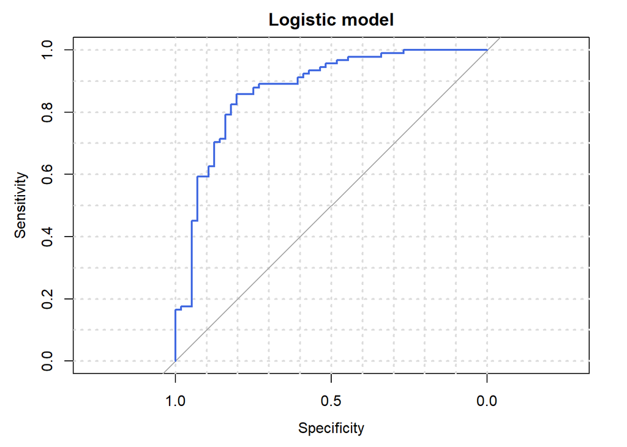

```r
require(pROC)

roc.logistica <- roc(plotdatam$diagnostico, fitted(regresion.logistica2), smooth=FALSE)
plot.roc(
  roc.logistica,
  grid=TRUE,
  grid.lwd=2,
  col="royalblue",
  main="Logistic model")
```

```r
roc.logistica$auc
```

```
## Area under the curve: 0.8717
```

Area under the curve: 0.8717.

# Regresion de lasso.

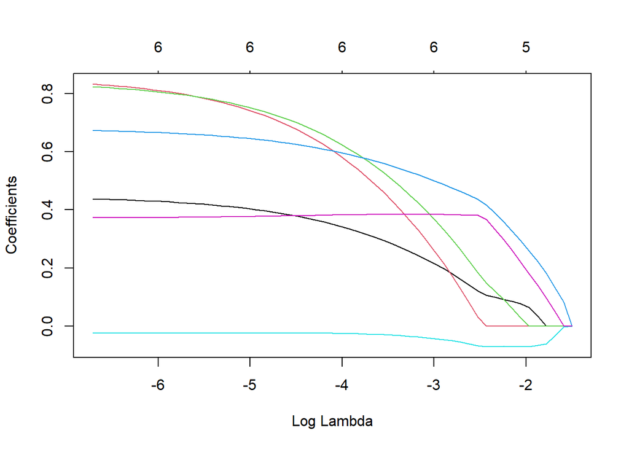

```r
library(glmnet)

lassoModel <- glmnet(
  x=data.matrix(plotdatam[,-1]),
  y=plotdatam$diagnostico,
  standardize=FALSE,
  alpha=1.0,
  nfolds=50,
  family="binomial")
plot(lassoModel, xvar="lambda")
```

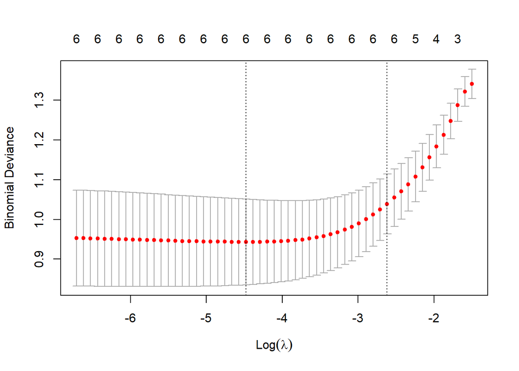

```r
cv.lassoModel <- cv.glmnet(
  x=data.matrix(plotdatam[,-1]),
  y=plotdatam$diagnostico,
  standardize=FALSE,
  alpha=1.0,
  nfolds=10,
  family="binomial",
  parallel = TRUE)
plot(cv.lassoModel, xvar="lambda")
```

Identificamos el mejor modelo

```r
best.model.lasso <- glmnet(
  x=plotdatam[,-1],
  y=plotdatam$diagnostico,
  standardize=FALSE,
  alpha=1.0,
  nfolds=50,
  family="binomial",
  lambda = cv.lassoModel$lambda.min)

coef(best.model.lasso)
```

```
## 7 x 1 sparse Matrix of class "dgCMatrix"
##                      s0
## (Intercept)   0.7102588
## ILMN_1735360  0.3774607
## ILMN_2075927  0.6743285
## ILMN_3299478  0.6981886
## ILMN_2210934  0.6245065
## ILMN_3280402 -0.0244396
## ILMN_1813573  0.3798724
```

Otra manera de comprobar el mejor modelo

```r
predict(lassoModel,s=cv.lassoModel$lambda.min,type="coef",mode="fraction")
```

```
## 7 x 1 sparse Matrix of class "dgCMatrix"
##                       s1
## (Intercept)   0.71021113
## ILMN_1735360  0.37735360
## ILMN_2075927  0.67391340
## ILMN_3299478  0.69803217
## ILMN_2210934  0.62455145
## ILMN_3280402 -0.02442814
## ILMN_1813573  0.38011151
```

No parece que debamos eliminar alguna variable predictora. El modelo original ya funciona bien. El LASSO no es necesario puesto que conserva todas las variables.

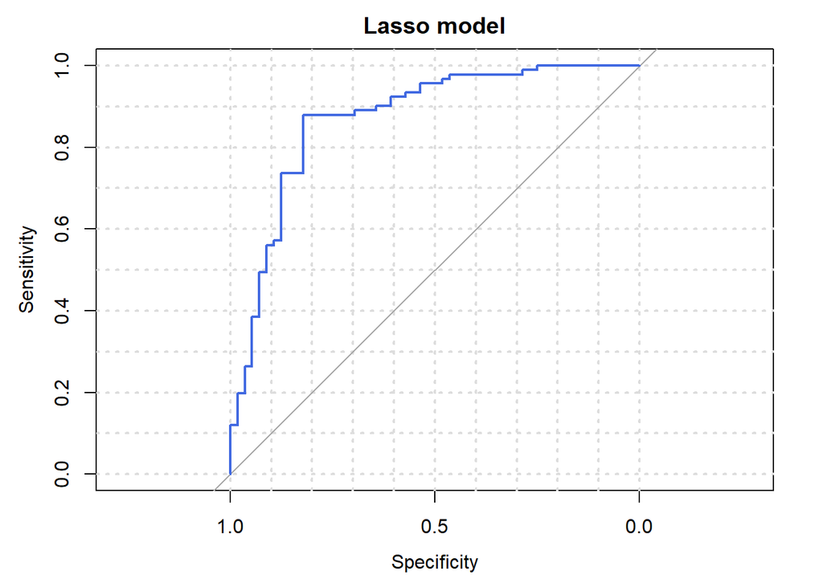

```r
#cambiamos de formato del mejor modelo

best.model.lasso2<-glm(plotdatam$diagnostico~.,data = plotdatam,family = binomial(link = "logit"))



# ROC analysis
require(pROC)

roc.lasso <- roc(plotdatam$diagnostico, fitted(best.model.lasso2), smooth=FALSE)
plot.roc(
  roc.lasso,
  grid=TRUE,
  grid.lwd=2,
  col="royalblue",
  main="Lasso model")
```

```r
roc.lasso$auc
```

```
## Area under the curve: 0.8703
```

Obtenemos un área bajo la curva de 0.8703 para este modelo, lo cual implica una buena discriminación entre pacientes con autismo y controles